# Proyecto 2. Resultados Parciales y Visualizaciones Estáticas

Marco Ramirez, Estuardo Hernandez, Alfredo Quezada

2022-10-31

## Investigación de posibles algoritmos a utilizar

### Naive Bayes

El algoritmo clasificador Naïve-Bayes (NBC), es un clasificador probabilístico simple con fuerte suposición de independencia. Aunque la suposición de la independencia de los atributos es generalmente una suposición pobre y se viola a menudo para los conjuntos de datos verdaderos. A menudo proporciona una mejor precisión de clasificación en conjuntos de datos en tiempo real que cualquier otro clasificador. También requiere una pequeña cantidad de datos de entrenamiento. El clasificador Naïve-Bayes aprende de los datos de entrenamiento y luego predice la clase de la instancia de prueba con la mayor probabilidad posterior. También es útil para datos dimensionales altos ya que la probabilidad de cada atributo se estima independientemente (Medium, 2019).

Las ventajas del modelo Naive Bayes son:

- Fácil de implementar y aplicar a diferentes casos como la clasificación de texto.
- Naive Bayes requiere una pequeña cantidad de datos de entrenamiento para estimar los datos de las pruebas.
- Menos esfuerzo de preparación de datos.

(Medium, 2019)

Las desventajas del modelo Naive Bayes son:

- Tiene la fuerte hipótesis de independencia variable.
- Si la variable categórica tiene una categoría en el conjunto de datos de prueba, que no se observó en el conjunto de datos de entrenamiento, entonces el modelo asignará una probabilidad 0 (cero). En este caso, debe añadirse una unidad de cada conjunto de datos.

(Medium, 2019)

### Gaussian Naive Bayes

Uno de los tipos de clasificadores más populares es el llamado en inglés Gaussian Naive Bayes Classifier. Este toma en cuenta la probabilidad, la verosimilitud y la probabilidad marginal. Los nombres Gaussian y Naive del algoritmo vienen de dos suposiciones: - Asumimos que las características de la verosimilitud no estan correlacionada entre ellas. Como no es siempre cierto y es una suposición ingenua es que aparece en el nombre “naive bayes”. - Asumimos que el valor de las características tendrá una distribución normal (gaussiana). Esto nos permite calcular cada parte usando la función de probabilidad de densidad normal (Aprende Machine Learning, 2017).

Las ventajas del modelo Gaussian Naive Bayes son:

- Es rápido.
- Es simple de implementar.
- Funciona bien con conjunto de datos pequeños.
- Va bien con muchas dimensiones (features).
- Llega a dar buenos resultados aún siendo “ingenuo” sin que se cumplan todas las condiciones de distribución necesarias en los datos.

(Aprende Machine Learning, 2017)

Las desventajas del modelo Gaussian Naive Bayes son:

- Requiere quitar las dimensiones con correlación.
- Para buenos resultados las entradas deberían cumplir las 2 suposiciones de distribución normal e independencia entre sí (muy difícil que sea así ó deberíamos hacer transformaciones en lo datos de entrada).

(Aprende Machine Learning, 2017)

### Multinomial Naive Bayes

El clasificador multinomial Naive Bayes es adecuado para la clasificación con características discretas, por ejemplo, recuento de palabras para la clasificación de texto. La distribución multinomial normalmente requiere recuentos de características de enteros. Sin embargo, en la práctica, los recuentos fraccionarios también pueden funcionar (Anguiano, 2009).

Se usa ampliamente para asignar documentos a clases en función del análisis estadístico de sus contenidos. Proporciona una alternativa al análisis semántico “pesado” basado en IA y simplifica drásticamente la clasificación de datos textuales. La clasificación tiene como objetivo asignar fragmentos de texto (es decir, documentos) a clases determinando la probabilidad de que un documento pertenezca a la clase de otros documentos que tengan el mismo asunto (Anguiano, 2009).

### Bayesian Network

Es un modelo grafo probabilístico, un tipo de modelo estático, que representa un conjunto de variables aleatorias y sus dependencias condicionales a través de un grafo acíclico dirigido (DAG por sus siglas en inglés). Por ejemplo, una red bayesiana puede representar las relaciones probabilísticas entre enfermedades y síntomas. Dados los síntomas, la red puede ser usada para computar la probabilidad de la presencia de varias enfermedades (Gal, 2007).

Formalmente, las redes bayesianas son grafos dirigidos acíclicos cuyos nodos representan variables aleatorias en el sentido de Bayes: las mismas pueden ser cantidades observables, variables latentes, parámetros desconocidos o hipótesis. Las aristas representan dependencias condicionales; los nodos que no se encuentran conectados representan variables las cuales son condicionalmente independientes de las otras. Cada nodo tiene asociado una función de probabilidad que toma como entrada un conjunto particular de valores de las variables padres del nodo y devuelve la probabilidad de la variable representada por el nodo (Gal, 2007).

Las ventajas del modelo Bayesian Network son:

- La representación gráfica la convierte en una poderosa herramienta de comunicación, las relaciones causa-efecto se visualizan fácilmente sin la necesidad del cálculo de probabilidades.
- La posibilidad de combinar datos objetivos y subjetivos, esto es una enorme ventaja sobre todo cuando no se cuentan con suficientes datos estadísticos.
- Pueden modelar sistemas complejos.
- La red puede actualizarse rápidamente o modificarse por cambios en la información o un mal desempeño.
- Pueden utilizarse para anális de “Que pasa si”, para analizar la sensibilidad de las predicciones, o conclusiones respecto de los supuestos iniciales.

(Gal, 2007)

Las desventajas del modelo Bayesian Network son:

- Las Redes Bayesianas tienen la desventaja de que el modelo es bueno tanto como el que modela lo sea y la percepción que tengan los expertos de la realidad.
- Otra limitación se relaciona con el hecho de que la utilidad de las RBs está basada en la confiabilidad de la información a priori. Un expectativa demasiado optimista o pesimista de las creencias a priori pueden ya sea distorsionar la red o invalidar los resultados. Seleccionar una apropiada distribución de los datos tiene un importante efecto en la calidad de los resultados de la red.

(Gal, 2007)

### Referencias

Aprende Machine Learning. (4 de Noviembre de 2017). Principales Algoritmos Usado en Machine Learning. Obtenido de https://www.aprendemachinelearning.com/principales-algoritmos-usados-en-machine-learning/

freeCodeCamp. (28 de Abril de 2021). Cómo funcionan los clasificadores Naive Bayes. Obtenido de https://www.freecodecamp.org/espanol/news/como-funcionan-los-clasificadores-naive-bayes-con-ejemplos-de-codigo-de-python/

Medium. (25 de Abril de 2019). Algoritmos Naive Bayes: Fundamentos e Implementación. Obtenido de https://medium.com/datos-y-ciencia/algoritmos-naive-bayes-fudamentos-e-implementación-4bcb24b307f

Anguiano, E. (29 de Abril de 2009). Naive Bayes Multinomial para Clasificación de Texto Usando un Esquema de Pesado por Clases. México.

Ben Gal I (2007). Redes bayesianas. En Ruggeri F, Kennett RS, Faltin FW (eds.). Página de soporte. Enciclopedia de Estadísticas en Calidad y Confiabilidad. John Wiley & Sons.

Borgelt C, Kruse R (marzo de 2002). Modelos gráficos: métodos de análisis y minería de datos. Chichester, Reino Unido : Wiley.

## Algoritmos y modelos seleccionados

Naive Bayes porque es el más simple en cuanto a clasificación de texto. Además de su fácil implementación. También porque estamos familiarizados con el teorema de Naive Bayes.

## Construcción de modelos

Para la elaboracion del modelo con el algoritmo Naive Bayes se llevaron a cabo los siguientes pasos: 1. Creacion de Corpus 2. Preprocesamiento de Corpus 3. Creacion de matriz 4. Creacion de datos de entrenamiento y prueba

```r
#Import libraries
library(tm)
library(SnowballC)
library(wordcloud)
library(RColorBrewer)
library(e1071)         #For Naive Bayes
library(caret)         #For the Confusion Matrix

library(gmodels) #provides CrossTable() function for comparison

db<-read.csv('train.csv')

db<-db[,c(3,5)]
colnames(db)<-c('Msg','Tag')

db$Tag<-factor(db$Tag)
# creating our corpus
text_corpus <- VCorpus(VectorSource(db$Msg))

# Viewing the content of more than one texts using lapply() function
lapply(text_corpus[1:5], as.character)
```

```
## $`1`
## [1] "Hi, i'm Isaac, i'm going to be writing about how this face on Mars is a natural landform or if there is life on Mars that made it. The story is about how NASA took a picture of Mars and a face was seen on the planet. NASA doesn't know if the landform was created by life on Mars, or if it is …
##
## $`2`
## [1] "On my perspective, I think that the face is a natural landform because I dont think that there is any life on Mars. In these next few paragraphs, I'll be talking about how I think that is is a natural landform "
##
## $`3`
## [1] "I think that the face is a natural landform because there is no life on Mars that we have descovered yet "
##
## $`4`
## [1] "If life was on Mars, we would know by now. The reason why I think it is a natural landform because, nobody live on Mars in order to create the figure. It says in paragraph 9, \"It's not easy to target Cydonia,\" in which he is saying that its not easy to know if it is a natural landform at t…
##
## $`5`
## [1] "People thought that the face was formed by alieans because they thought that there was life on Mars. "
```

```r
cleanCorpus <- tm_map(text_corpus, content_transformer(tolower)) # lowercase all texts
cleanCorpus <- tm_map(cleanCorpus, removeNumbers) # remove all numbers
cleanCorpus <- tm_map(cleanCorpus, removeWords, stopwords('english')) # remove all common words such as to, but and etc.
cleanCorpus <- tm_map(cleanCorpus, removePunctuation) # remove all punctuation
cleanCorpus <- tm_map(cleanCorpus, stripWhitespace) # remove all whitespace

text_dtm <- DocumentTermMatrix(cleanCorpus)


# Creating train and test portions
porcentaje<-0.7
set.seed(123)
corte <- sample(nrow(text_dtm),nrow(text_dtm)*porcentaje)

train <- text_dtm[corte,] # 70% for training
test <- text_dtm[-corte, ] # 30% for testing
train_type <- db[corte, ]$Tag
test_type <- db[-corte, ]$Tag


#training portion
tbl_train <- prop.table(table(train_type))

#testing portion
tbl_test <- prop.table(table(test_type))


freq_words <- findFreqTerms(train, 5)
str(freq_words)
```

```
##  chr [1:5977] "   " "    " " student" "aap" "abilities" "ability" "able" ...
```

```r
# Selecting only the frequent words from the train and test datasets
freq_words_train <- train[ , freq_words]
freq_words_test <- test[ , freq_words]


# creating a function for conversion
convert <- function(x) {x <- ifelse(x > 0, "y", "n")}
train <- apply(freq_words_train, MARGIN = 2, convert)
test <- apply(freq_words_test, MARGIN = 2, convert)


# Creating a Naive Bayes classifier
sms_classifier <- naiveBayes(train, train_type)
# Making prediction & evaluation with the classifier
test_prediction <- predict(sms_classifier, test)

CrossTable(test_prediction, test_type,
           prop.chisq = FALSE, prop.t = FALSE,
           dnn = c('predicted', 'actual'))
```

```
##
##
##    Cell Contents
## |-------------------------|
## |                       N |
## |           N / Row Total |
## |           N / Col Total |
## |-------------------------|
##
##
## Total Observations in Table:  11030
##
##
##              | actual
##    predicted |    Adequate |   Effective | Ineffective |   Row Total |
## -------------|-------------|-------------|-------------|-------------|
##     Adequate |        4542 |        1278 |        1216 |        7036 |
##              |       0.646 |       0.182 |       0.173 |       0.638 |
##              |       0.726 |       0.455 |       0.619 |             |
## -------------|-------------|-------------|-------------|-------------|
##    Effective |         753 |        1331 |         118 |        2202 |
##              |       0.342 |       0.604 |       0.054 |       0.200 |
##              |       0.120 |       0.474 |       0.060 |             |
## -------------|-------------|-------------|-------------|-------------|
##  Ineffective |         962 |         198 |         632 |        1792 |
##              |       0.537 |       0.110 |       0.353 |       0.162 |
##              |       0.154 |       0.071 |       0.321 |             |
## -------------|-------------|-------------|-------------|-------------|
## Column Total |        6257 |        2807 |        1966 |       11030 |
##              |       0.567 |       0.254 |       0.178 |             |
## -------------|-------------|-------------|-------------|-------------|
##
##
```

```r
#Modelo 2
sms_classifier_improved <- naiveBayes(train, train_type, laplace = 1)
test_prediction_improved <- predict(sms_classifier_improved, test)

CrossTable(test_prediction_improved, test_type,
           prop.chisq = FALSE, prop.t = FALSE,
           dnn = c('predicted', 'actual'))
```

```
##
##
##    Cell Contents
## |-------------------------|
## |                       N |
## |           N / Row Total |
## |           N / Col Total |
## |-------------------------|
##
##
## Total Observations in Table:  11030
##
##
##              | actual
##    predicted |    Adequate |   Effective | Ineffective |   Row Total |
## -------------|-------------|-------------|-------------|-------------|
##     Adequate |        4256 |        1201 |        1104 |        6561 |
##              |       0.649 |       0.183 |       0.168 |       0.595 |
##              |       0.680 |       0.428 |       0.562 |             |
## -------------|-------------|-------------|-------------|-------------|
##    Effective |         791 |        1362 |         117 |        2270 |
##              |       0.348 |       0.600 |       0.052 |       0.206 |
##              |       0.126 |       0.485 |       0.060 |             |
## -------------|-------------|-------------|-------------|-------------|
##  Ineffective |        1210 |         244 |         745 |        2199 |
##              |       0.550 |       0.111 |       0.339 |       0.199 |
##              |       0.193 |       0.087 |       0.379 |             |
## -------------|-------------|-------------|-------------|-------------|
## Column Total |        6257 |        2807 |        1966 |       11030 |
##              |       0.567 |       0.254 |       0.178 |             |
## -------------|-------------|-------------|-------------|-------------|
##
##
```

## Discusión

Ambos modelos son muy similares en cuanto a los resultados, tienen la misma precisión a la hora de predecir excepto al clasificar argumentos ineficaces, el primer modelo arroja una precisión de 35% y el segundo un 34%, sigue siendo una precisión muy similar. Para argumentos adecuados y efectivos se obtuvo precisiones de 65% y 60% en ambos modelos. Se comprueba que el algoritmo de Naive Bayes es eficaz en la aplicación de clasificación de textos sin necesidad de muchos recursos.

Los NBC escalan muy bien, lo que significa que podemos agregar muchas más funciones y el algoritmo seguirá siendo rápido y confiable. Incluso en el caso de que los NBC no fueran adecuados para el problema que se está tratando de resolver, podrían ser útiles como referencia.

## Visualizaciones estáticas

Frecuencia de las palabras en los argumentos que son clasificados como “Adequate” representada en una nube de palabras.

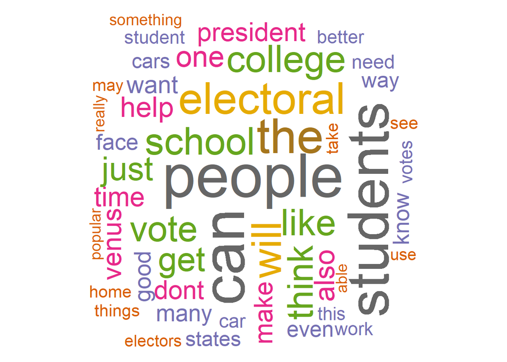

```r
wordcloud(spamText$Msg, max.words = 50, scale = c(5, 0.3),random.order = FALSE, rot.per = 0.15, colors = brewer.pal(8, "Dark2"))
```

Frecuencia de las palabras en los argumentos que son clasificados como “Effective” representada en una nube de palabras.

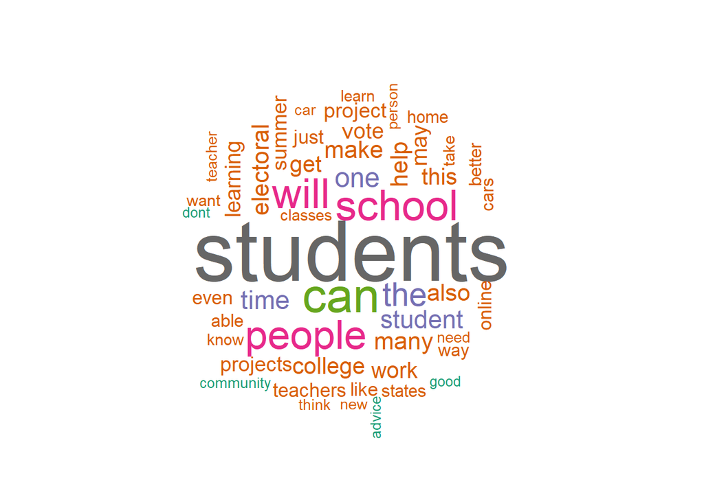

```r
wordcloud(amText$Msg, max.words = 50, scale = c(5, 0.3),random.order = FALSE, rot.per = 0.15, colors = brewer.pal(8, "Dark2"))
```

Frecuencia de las palabras en los argumentos que son clasificados como “Ineffective” representada en una nube de palabras.

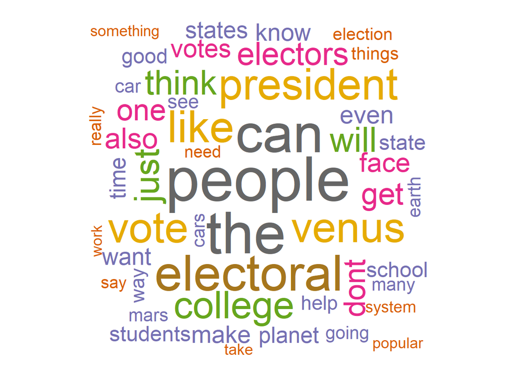

```r
wordcloud(hamText$Msg, max.words = 50, scale = c(5, 0.3),random.order = FALSE, rot.per = 0.15, colors = brewer.pal(8, "Dark2"))
```